# examples_0122

To answer this question, open a [new SketchUp](https://app.sketchup.com) with *Decimal - Meters* as your units. In this problem, assume all lengths are in meters and all volumes are in cubic meters.

- Generate a rectangular prism, with $w=9.1$, $d=7.4$, and $h=6.8$, with a corner on the origin:
  - Draw a rectangle with one corner on the origin. Dimensions: 9.1 by 7.4. Make sure the rectangle will pull up along the blue axis.
  - Pull the rectangle up by 6.8 meters (in direction of blue axis).
  - Triple click the object to highlight everything.
  - Right click and Make Group.
- Generate a cylinder with radius $r=4.9$ and height $h=3.8$ so that the bottom face's center is at the origin.
  - Draw a circle with radius $4.9$ with its center at the origin. Make sure the circle will pull up along the blue axis.
  - Pull the circle up by 3.8 meters (in direction of blue axis).
  - Triple click the object to highlight everything.
  - Right click and Make Group.

We will practice using the `Union`, `Intersection`, and `Subtract` functions in SketchUp. To find the volume of an object, click on it and then open the `Entity Info` (button is top-right of window). The volume will be shown there.

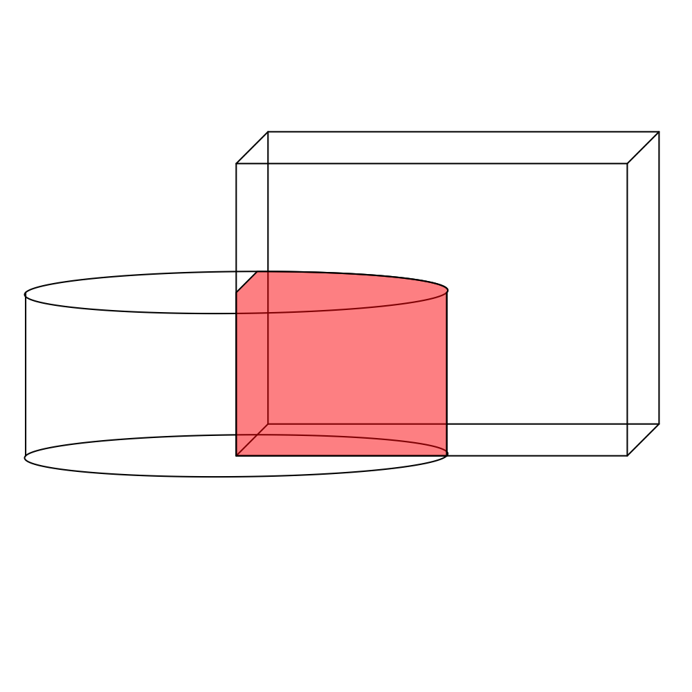

- What is the volume of the rectangular prism?
- $\mathrm{m^3}$
- What is the volume of the cylinder?
- $\mathrm{m^3}$
- What is the volume of the union between the prism and the cylinder?
- $\mathrm{m^3}$
- What is the volume of the intersection between the prism and the cylinder?
- $\mathrm{m^3}$
- What is the volume of the subtraction of the cylinder from prism? (click cylinder then prism)
- $\mathrm{m^3}$
- What is the volume of the subtraction of the prism from cylinder? (click prism then cylinder)
- $\mathrm{m^3}$
- The volume of the rectangular prism: 458 $\mathrm{m^3}$
- The volume of the cylinder: 283 $\mathrm{m^3}$
- The volume of the union: 670 $\mathrm{m^3}$
- The volume of the intersection: 71 $\mathrm{m^3}$
- The volume of the subtraction of cylinder from prism: 387 $\mathrm{m^3}$
- The volume of the subtraction of prism from cylinder: 213 $\mathrm{m^3}$

To answer this question, open a [new SketchUp](https://app.sketchup.com) with *Decimal - Meters* as your units. In this problem, assume all lengths are in meters and all volumes are in cubic meters.

- Generate a rectangular prism, with $w=7.4$, $d=6.7$, and $h=5.4$, with a corner on the origin:
  - Draw a rectangle with one corner on the origin. Dimensions: 7.4 by 6.7. Make sure the rectangle will pull up along the blue axis.
  - Pull the rectangle up by 5.4 meters (in direction of blue axis).
  - Triple click the object to highlight everything.
  - Right click and Make Group.
- Generate a cylinder with radius $r=5.9$ and height $h=4.4$ so that the bottom face's center is at the origin.
  - Draw a circle with radius $5.9$ with its center at the origin. Make sure the circle will pull up along the blue axis.
  - Pull the circle up by 4.4 meters (in direction of blue axis).
  - Triple click the object to highlight everything.
  - Right click and Make Group.

We will practice using the `Union`, `Intersection`, and `Subtract` functions in SketchUp. To find the volume of an object, click on it and then open the `Entity Info` (button is top-right of window). The volume will be shown there.

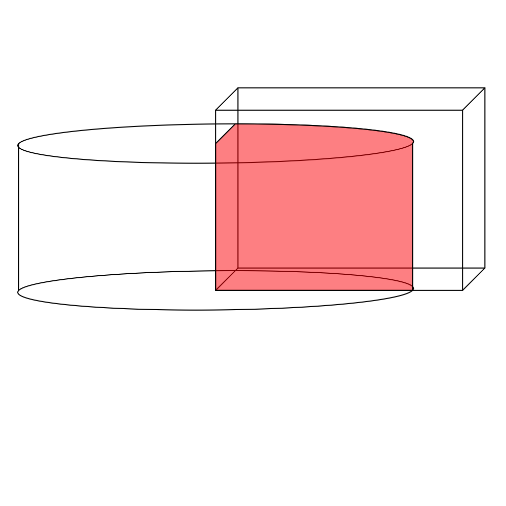

- What is the volume of the rectangular prism?
- $\mathrm{m^3}$
- What is the volume of the cylinder?
- $\mathrm{m^3}$
- What is the volume of the union between the prism and the cylinder?
- $\mathrm{m^3}$
- What is the volume of the intersection between the prism and the cylinder?
- $\mathrm{m^3}$
- What is the volume of the subtraction of the cylinder from prism? (click cylinder then prism)
- $\mathrm{m^3}$
- What is the volume of the subtraction of the prism from cylinder? (click prism then cylinder)
- $\mathrm{m^3}$
- The volume of the rectangular prism: 268 $\mathrm{m^3}$
- The volume of the cylinder: 476 $\mathrm{m^3}$
- The volume of the union: 625 $\mathrm{m^3}$
- The volume of the intersection: 119 $\mathrm{m^3}$
- The volume of the subtraction of cylinder from prism: 149 $\mathrm{m^3}$
- The volume of the subtraction of prism from cylinder: 357 $\mathrm{m^3}$

To answer this question, open a [new SketchUp](https://app.sketchup.com) with *Decimal - Meters* as your units. In this problem, assume all lengths are in meters and all volumes are in cubic meters.

- Generate a rectangular prism, with $w=6.6$, $d=7.3$, and $h=6$, with a corner on the origin:
  - Draw a rectangle with one corner on the origin. Dimensions: 6.6 by 7.3. Make sure the rectangle will pull up along the blue axis.
  - Pull the rectangle up by 6 meters (in direction of blue axis).
  - Triple click the object to highlight everything.
  - Right click and Make Group.
- Generate a cylinder with radius $r=5.4$ and height $h=9.8$ so that the bottom face's center is at the origin.
  - Draw a circle with radius $5.4$ with its center at the origin. Make sure the circle will pull up along the blue axis.
  - Pull the circle up by 9.8 meters (in direction of blue axis).
  - Triple click the object to highlight everything.
  - Right click and Make Group.

We will practice using the `Union`, `Intersection`, and `Subtract` functions in SketchUp. To find the volume of an object, click on it and then open the `Entity Info` (button is top-right of window). The volume will be shown there.

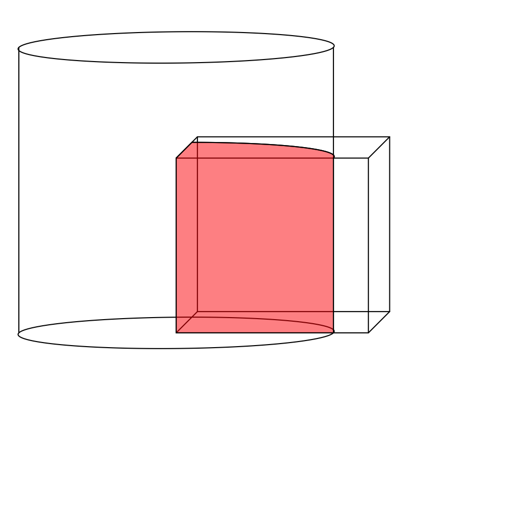

- What is the volume of the rectangular prism?
- $\mathrm{m^3}$
- What is the volume of the cylinder?
- $\mathrm{m^3}$
- What is the volume of the union between the prism and the cylinder?
- $\mathrm{m^3}$
- What is the volume of the intersection between the prism and the cylinder?
- $\mathrm{m^3}$
- What is the volume of the subtraction of the cylinder from prism? (click cylinder then prism)
- $\mathrm{m^3}$
- What is the volume of the subtraction of the prism from cylinder? (click prism then cylinder)
- $\mathrm{m^3}$
- The volume of the rectangular prism: 289 $\mathrm{m^3}$
- The volume of the cylinder: 888 $\mathrm{m^3}$
- The volume of the union: 1041 $\mathrm{m^3}$
- The volume of the intersection: 136 $\mathrm{m^3}$
- The volume of the subtraction of cylinder from prism: 153 $\mathrm{m^3}$
- The volume of the subtraction of prism from cylinder: 752 $\mathrm{m^3}$

To answer this question, open a [new SketchUp](https://app.sketchup.com) with *Decimal - Meters* as your units. In this problem, assume all lengths are in meters and all volumes are in cubic meters.

- Generate a rectangular prism, with $w=5.4$, $d=8.8$, and $h=5.5$, with a corner on the origin:
  - Draw a rectangle with one corner on the origin. Dimensions: 5.4 by 8.8. Make sure the rectangle will pull up along the blue axis.
  - Pull the rectangle up by 5.5 meters (in direction of blue axis).
  - Triple click the object to highlight everything.
  - Right click and Make Group.
- Generate a cylinder with radius $r=4.7$ and height $h=3.6$ so that the bottom face's center is at the origin.
  - Draw a circle with radius $4.7$ with its center at the origin. Make sure the circle will pull up along the blue axis.
  - Pull the circle up by 3.6 meters (in direction of blue axis).
  - Triple click the object to highlight everything.
  - Right click and Make Group.

We will practice using the `Union`, `Intersection`, and `Subtract` functions in SketchUp. To find the volume of an object, click on it and then open the `Entity Info` (button is top-right of window). The volume will be shown there.

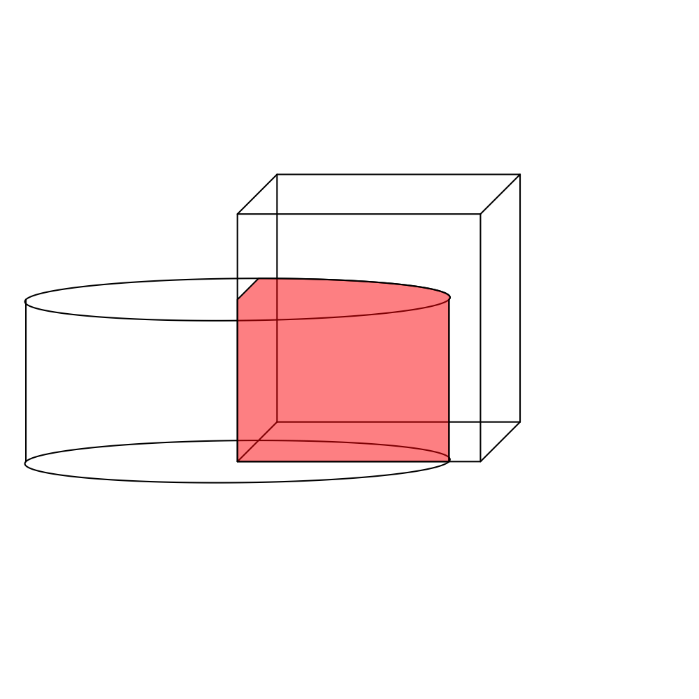

- What is the volume of the rectangular prism?
- $\mathrm{m^3}$
- What is the volume of the cylinder?
- $\mathrm{m^3}$
- What is the volume of the union between the prism and the cylinder?
- $\mathrm{m^3}$
- What is the volume of the intersection between the prism and the cylinder?
- $\mathrm{m^3}$
- What is the volume of the subtraction of the cylinder from prism? (click cylinder then prism)
- $\mathrm{m^3}$
- What is the volume of the subtraction of the prism from cylinder? (click prism then cylinder)
- $\mathrm{m^3}$
- The volume of the rectangular prism: 261 $\mathrm{m^3}$
- The volume of the cylinder: 247 $\mathrm{m^3}$
- The volume of the union: 447 $\mathrm{m^3}$
- The volume of the intersection: 62 $\mathrm{m^3}$
- The volume of the subtraction of cylinder from prism: 200 $\mathrm{m^3}$
- The volume of the subtraction of prism from cylinder: 185 $\mathrm{m^3}$

To answer this question, open a [new SketchUp](https://app.sketchup.com) with *Decimal - Meters* as your units. In this problem, assume all lengths are in meters and all volumes are in cubic meters.

- Generate a rectangular prism, with $w=6.2$, $d=5.1$, and $h=7$, with a corner on the origin:
  - Draw a rectangle with one corner on the origin. Dimensions: 6.2 by 5.1. Make sure the rectangle will pull up along the blue axis.
  - Pull the rectangle up by 7 meters (in direction of blue axis).
  - Triple click the object to highlight everything.
  - Right click and Make Group.
- Generate a cylinder with radius $r=4.6$ and height $h=7.4$ so that the bottom face's center is at the origin.
  - Draw a circle with radius $4.6$ with its center at the origin. Make sure the circle will pull up along the blue axis.
  - Pull the circle up by 7.4 meters (in direction of blue axis).
  - Triple click the object to highlight everything.
  - Right click and Make Group.

We will practice using the `Union`, `Intersection`, and `Subtract` functions in SketchUp. To find the volume of an object, click on it and then open the `Entity Info` (button is top-right of window). The volume will be shown there.

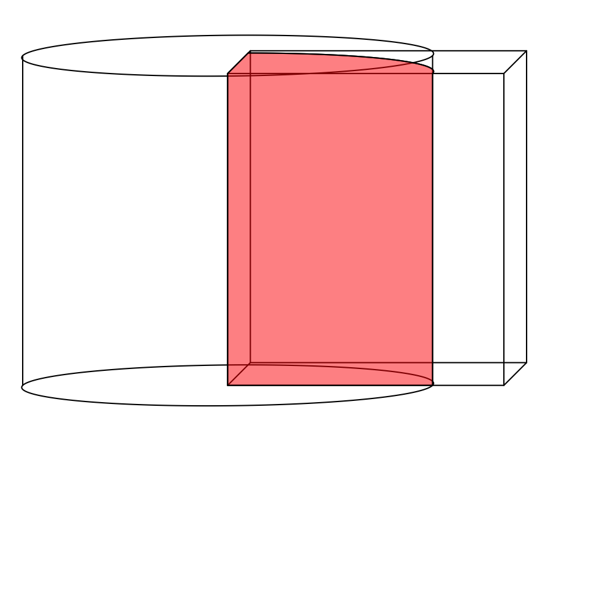

- What is the volume of the rectangular prism?
- $\mathrm{m^3}$
- What is the volume of the cylinder?
- $\mathrm{m^3}$
- What is the volume of the union between the prism and the cylinder?
- $\mathrm{m^3}$
- What is the volume of the intersection between the prism and the cylinder?
- $\mathrm{m^3}$
- What is the volume of the subtraction of the cylinder from prism? (click cylinder then prism)
- $\mathrm{m^3}$
- What is the volume of the subtraction of the prism from cylinder? (click prism then cylinder)
- $\mathrm{m^3}$
- The volume of the rectangular prism: 221 $\mathrm{m^3}$
- The volume of the cylinder: 486 $\mathrm{m^3}$
- The volume of the union: 593 $\mathrm{m^3}$
- The volume of the intersection: 115 $\mathrm{m^3}$
- The volume of the subtraction of cylinder from prism: 106 $\mathrm{m^3}$
- The volume of the subtraction of prism from cylinder: 371 $\mathrm{m^3}$

To answer this question, open a [new SketchUp](https://app.sketchup.com) with *Decimal - Meters* as your units. In this problem, assume all lengths are in meters and all volumes are in cubic meters.

- Generate a rectangular prism, with $w=9.5$, $d=8.6$, and $h=7.3$, with a corner on the origin:
  - Draw a rectangle with one corner on the origin. Dimensions: 9.5 by 8.6. Make sure the rectangle will pull up along the blue axis.
  - Pull the rectangle up by 7.3 meters (in direction of blue axis).
  - Triple click the object to highlight everything.
  - Right click and Make Group.
- Generate a cylinder with radius $r=7.4$ and height $h=6.2$ so that the bottom face's center is at the origin.
  - Draw a circle with radius $7.4$ with its center at the origin. Make sure the circle will pull up along the blue axis.
  - Pull the circle up by 6.2 meters (in direction of blue axis).
  - Triple click the object to highlight everything.
  - Right click and Make Group.

We will practice using the `Union`, `Intersection`, and `Subtract` functions in SketchUp. To find the volume of an object, click on it and then open the `Entity Info` (button is top-right of window). The volume will be shown there.

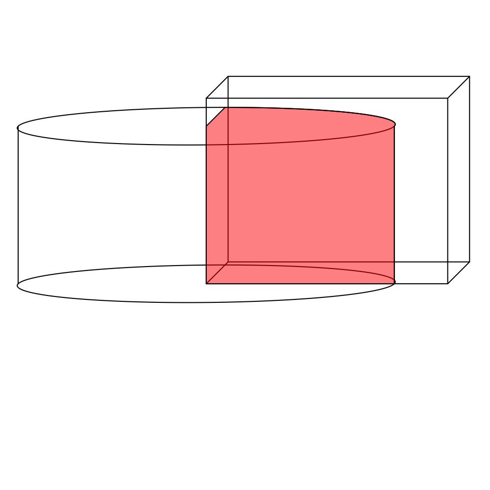

- What is the volume of the rectangular prism?
- $\mathrm{m^3}$
- What is the volume of the cylinder?
- $\mathrm{m^3}$
- What is the volume of the union between the prism and the cylinder?
- $\mathrm{m^3}$
- What is the volume of the intersection between the prism and the cylinder?
- $\mathrm{m^3}$
- What is the volume of the subtraction of the cylinder from prism? (click cylinder then prism)
- $\mathrm{m^3}$
- What is the volume of the subtraction of the prism from cylinder? (click prism then cylinder)
- $\mathrm{m^3}$
- The volume of the rectangular prism: 596 $\mathrm{m^3}$
- The volume of the cylinder: 1054 $\mathrm{m^3}$
- The volume of the union: 1387 $\mathrm{m^3}$
- The volume of the intersection: 264 $\mathrm{m^3}$
- The volume of the subtraction of cylinder from prism: 333 $\mathrm{m^3}$
- The volume of the subtraction of prism from cylinder: 791 $\mathrm{m^3}$

To answer this question, open a [new SketchUp](https://app.sketchup.com) with *Decimal - Meters* as your units. In this problem, assume all lengths are in meters and all volumes are in cubic meters.

- Generate a rectangular prism, with $w=7.6$, $d=6$, and $h=6.3$, with a corner on the origin:
  - Draw a rectangle with one corner on the origin. Dimensions: 7.6 by 6. Make sure the rectangle will pull up along the blue axis.
  - Pull the rectangle up by 6.3 meters (in direction of blue axis).
  - Triple click the object to highlight everything.
  - Right click and Make Group.
- Generate a cylinder with radius $r=5.4$ and height $h=10.3$ so that the bottom face's center is at the origin.
  - Draw a circle with radius $5.4$ with its center at the origin. Make sure the circle will pull up along the blue axis.
  - Pull the circle up by 10.3 meters (in direction of blue axis).
  - Triple click the object to highlight everything.
  - Right click and Make Group.

We will practice using the `Union`, `Intersection`, and `Subtract` functions in SketchUp. To find the volume of an object, click on it and then open the `Entity Info` (button is top-right of window). The volume will be shown there.

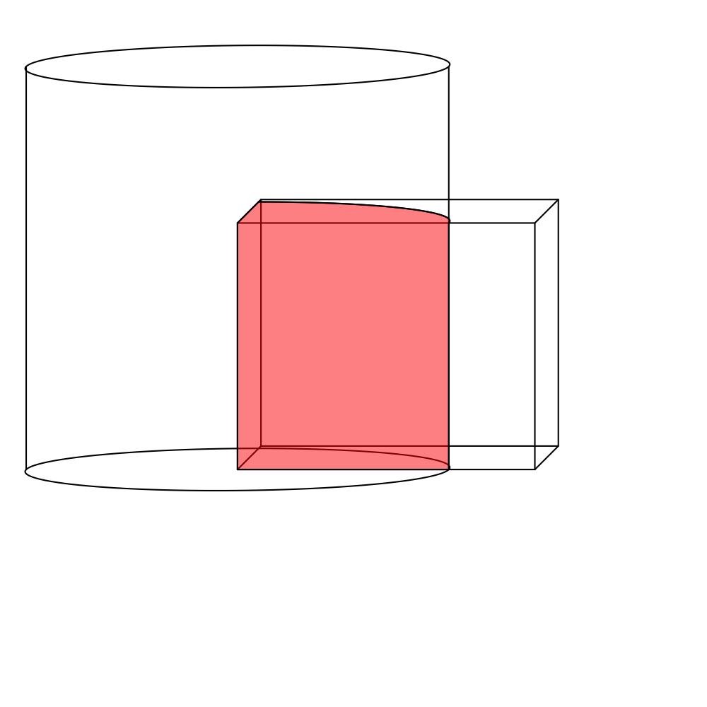

- What is the volume of the rectangular prism?
- $\mathrm{m^3}$
- What is the volume of the cylinder?
- $\mathrm{m^3}$
- What is the volume of the union between the prism and the cylinder?
- $\mathrm{m^3}$
- What is the volume of the intersection between the prism and the cylinder?
- $\mathrm{m^3}$
- What is the volume of the subtraction of the cylinder from prism? (click cylinder then prism)
- $\mathrm{m^3}$
- What is the volume of the subtraction of the prism from cylinder? (click prism then cylinder)
- $\mathrm{m^3}$
- The volume of the rectangular prism: 287 $\mathrm{m^3}$
- The volume of the cylinder: 933 $\mathrm{m^3}$
- The volume of the union: 1077 $\mathrm{m^3}$
- The volume of the intersection: 143 $\mathrm{m^3}$
- The volume of the subtraction of cylinder from prism: 145 $\mathrm{m^3}$
- The volume of the subtraction of prism from cylinder: 790 $\mathrm{m^3}$

To answer this question, open a [new SketchUp](https://app.sketchup.com) with *Decimal - Meters* as your units. In this problem, assume all lengths are in meters and all volumes are in cubic meters.

- Generate a rectangular prism, with $w=9.2$, $d=9$, and $h=8.9$, with a corner on the origin:
  - Draw a rectangle with one corner on the origin. Dimensions: 9.2 by 9. Make sure the rectangle will pull up along the blue axis.
  - Pull the rectangle up by 8.9 meters (in direction of blue axis).
  - Triple click the object to highlight everything.
  - Right click and Make Group.
- Generate a cylinder with radius $r=5.4$ and height $h=16.8$ so that the bottom face's center is at the origin.
  - Draw a circle with radius $5.4$ with its center at the origin. Make sure the circle will pull up along the blue axis.
  - Pull the circle up by 16.8 meters (in direction of blue axis).
  - Triple click the object to highlight everything.
  - Right click and Make Group.

We will practice using the `Union`, `Intersection`, and `Subtract` functions in SketchUp. To find the volume of an object, click on it and then open the `Entity Info` (button is top-right of window). The volume will be shown there.

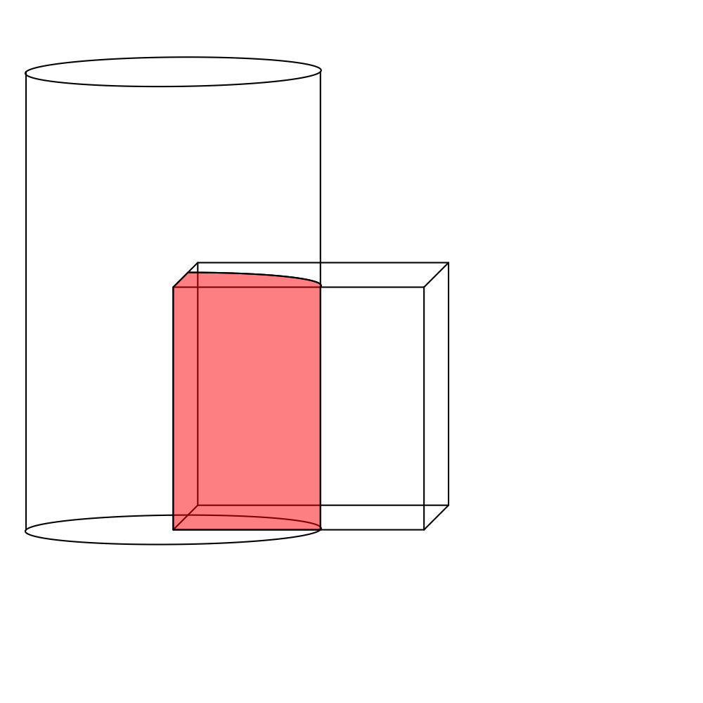

- What is the volume of the rectangular prism?
- $\mathrm{m^3}$
- What is the volume of the cylinder?
- $\mathrm{m^3}$
- What is the volume of the union between the prism and the cylinder?
- $\mathrm{m^3}$
- What is the volume of the intersection between the prism and the cylinder?
- $\mathrm{m^3}$
- What is the volume of the subtraction of the cylinder from prism? (click cylinder then prism)
- $\mathrm{m^3}$
- What is the volume of the subtraction of the prism from cylinder? (click prism then cylinder)
- $\mathrm{m^3}$
- The volume of the rectangular prism: 737 $\mathrm{m^3}$
- The volume of the cylinder: 1521 $\mathrm{m^3}$
- The volume of the union: 2057 $\mathrm{m^3}$
- The volume of the intersection: 202 $\mathrm{m^3}$
- The volume of the subtraction of cylinder from prism: 535 $\mathrm{m^3}$
- The volume of the subtraction of prism from cylinder: 1320 $\mathrm{m^3}$

To answer this question, open a [new SketchUp](https://app.sketchup.com) with *Decimal - Meters* as your units. In this problem, assume all lengths are in meters and all volumes are in cubic meters.

- Generate a rectangular prism, with $w=7.3$, $d=5$, and $h=8.6$, with a corner on the origin:
  - Draw a rectangle with one corner on the origin. Dimensions: 7.3 by 5. Make sure the rectangle will pull up along the blue axis.
  - Pull the rectangle up by 8.6 meters (in direction of blue axis).
  - Triple click the object to highlight everything.
  - Right click and Make Group.
- Generate a cylinder with radius $r=3.9$ and height $h=10.6$ so that the bottom face's center is at the origin.
  - Draw a circle with radius $3.9$ with its center at the origin. Make sure the circle will pull up along the blue axis.
  - Pull the circle up by 10.6 meters (in direction of blue axis).
  - Triple click the object to highlight everything.
  - Right click and Make Group.

We will practice using the `Union`, `Intersection`, and `Subtract` functions in SketchUp. To find the volume of an object, click on it and then open the `Entity Info` (button is top-right of window). The volume will be shown there.

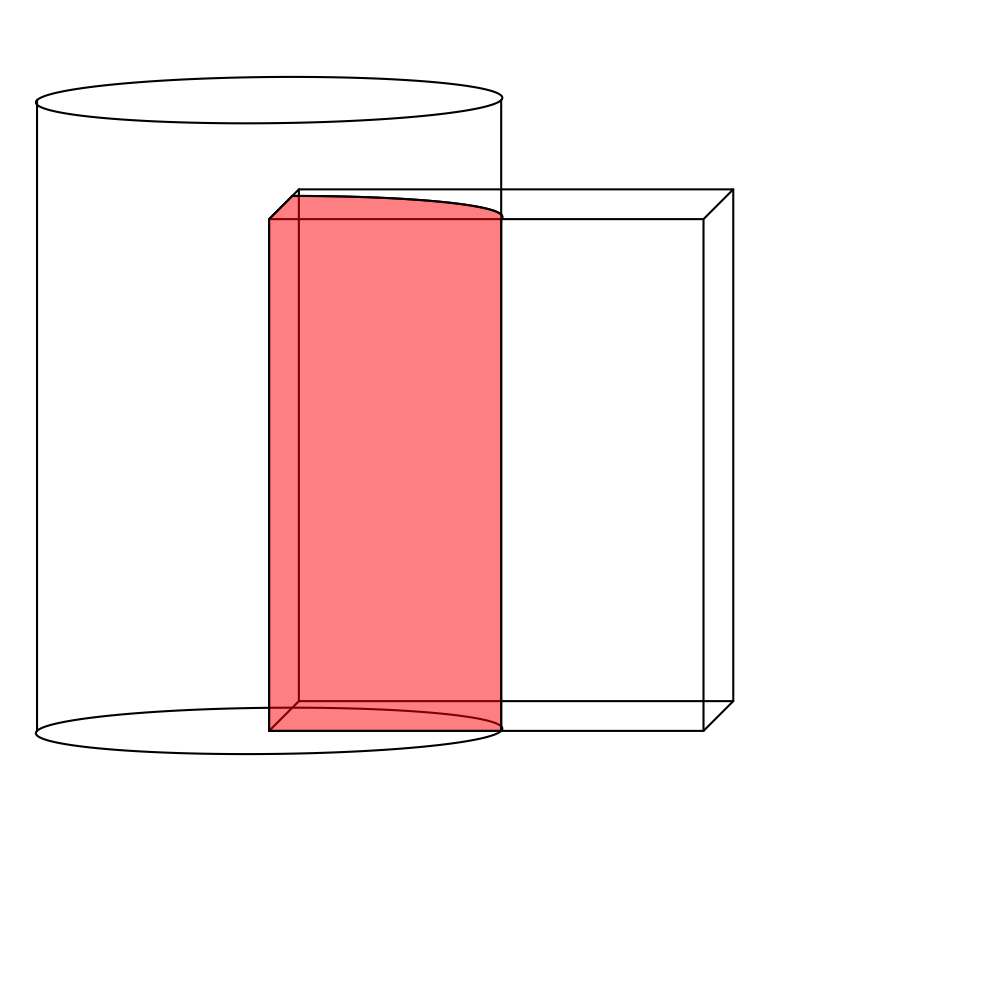

- What is the volume of the rectangular prism?
- $\mathrm{m^3}$
- What is the volume of the cylinder?
- $\mathrm{m^3}$
- What is the volume of the union between the prism and the cylinder?
- $\mathrm{m^3}$
- What is the volume of the intersection between the prism and the cylinder?
- $\mathrm{m^3}$
- What is the volume of the subtraction of the cylinder from prism? (click cylinder then prism)
- $\mathrm{m^3}$
- What is the volume of the subtraction of the prism from cylinder? (click prism then cylinder)
- $\mathrm{m^3}$
- The volume of the rectangular prism: 314 $\mathrm{m^3}$
- The volume of the cylinder: 501 $\mathrm{m^3}$
- The volume of the union: 713 $\mathrm{m^3}$
- The volume of the intersection: 102 $\mathrm{m^3}$
- The volume of the subtraction of cylinder from prism: 212 $\mathrm{m^3}$
- The volume of the subtraction of prism from cylinder: 399 $\mathrm{m^3}$

To answer this question, open a [new SketchUp](https://app.sketchup.com) with *Decimal - Meters* as your units. In this problem, assume all lengths are in meters and all volumes are in cubic meters.

- Generate a rectangular prism, with $w=9.9$, $d=8.5$, and $h=8.2$, with a corner on the origin:
  - Draw a rectangle with one corner on the origin. Dimensions: 9.9 by 8.5. Make sure the rectangle will pull up along the blue axis.
  - Pull the rectangle up by 8.2 meters (in direction of blue axis).
  - Triple click the object to highlight everything.
  - Right click and Make Group.
- Generate a cylinder with radius $r=8.4$ and height $h=8.8$ so that the bottom face's center is at the origin.
  - Draw a circle with radius $8.4$ with its center at the origin. Make sure the circle will pull up along the blue axis.
  - Pull the circle up by 8.8 meters (in direction of blue axis).
  - Triple click the object to highlight everything.
  - Right click and Make Group.

We will practice using the `Union`, `Intersection`, and `Subtract` functions in SketchUp. To find the volume of an object, click on it and then open the `Entity Info` (button is top-right of window). The volume will be shown there.

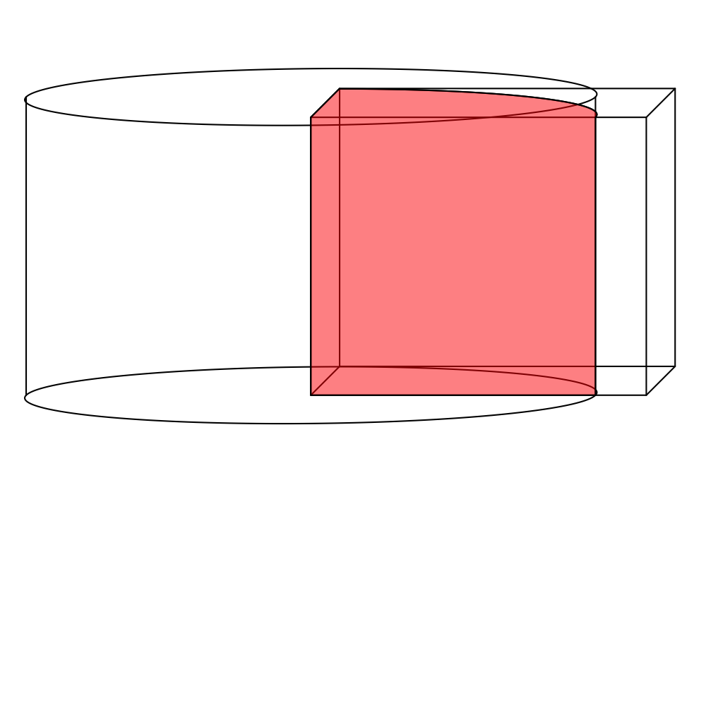

- What is the volume of the rectangular prism?
- $\mathrm{m^3}$
- What is the volume of the cylinder?
- $\mathrm{m^3}$
- What is the volume of the union between the prism and the cylinder?
- $\mathrm{m^3}$
- What is the volume of the intersection between the prism and the cylinder?
- $\mathrm{m^3}$
- What is the volume of the subtraction of the cylinder from prism? (click cylinder then prism)
- $\mathrm{m^3}$
- What is the volume of the subtraction of the prism from cylinder? (click prism then cylinder)
- $\mathrm{m^3}$
- The volume of the rectangular prism: 690 $\mathrm{m^3}$
- The volume of the cylinder: 1928 $\mathrm{m^3}$
- The volume of the union: 2169 $\mathrm{m^3}$
- The volume of the intersection: 449 $\mathrm{m^3}$
- The volume of the subtraction of cylinder from prism: 241 $\mathrm{m^3}$
- The volume of the subtraction of prism from cylinder: 1479 $\mathrm{m^3}$